# Dietary Advice App Trial: Data Analysis Assessment 2025–2026

- Show All Code
- Hide All Code
- View Source

Data preparation and hypothesis tests (Tasks 1–7)

Author

AAmalAzhari

Published

October 14, 2026

# Overview

This report analyses a two-arm trial of a **dietary advice app** (*No app* vs *On app*). Weight was measured at baseline and after 3 months. The report contains data preparation (Part A) and seven tasks (Part B). Each task states the question, the test chosen and why, the null hypothesis, the assumptions (with the checks run on the data), the results and the conclusion. All numbers in the text are computed from the data when the document is rendered.

# Data dictionary

Variables in the dietary advice app trial dataset

| Variable name | Description | Values |
| --- | --- | --- |
| `PID` | Participant ID |  |
| `agegroup` | Age group in years | 1 = 18-24; 2 = 25-29; 3 = 30-34; 4 = 35-40 |
| `sex` | Sex of participant | 0 = female; 1 = male |
| `height` | Height (m) |  |
| `app` | Use of dietary advice app | 0 = No app; 1 = On app |
| `orexigenic` | On orexigenic medication (appetite stimulant) | 0 = Yes; 1 = No |
| `weightbase` | Weight at baseline (kg) |  |
| `residence` | Residential area | 0 = urban; 1 = suburban; 2 = rural |
| `exercise` | Number of times exercise taken for at least 30 minutes in last month |  |
| `weight3mnths` | Weight after 3 months (kg) |  |

Three further variables are derived in Part A: `weightdiff` (weight at 3 months minus baseline, kg), `BMI3mnths` (BMI at 3 months, kg/m<sup>2</sup>) and `BMIGrouping` (underweight, normal weight, overweight, obese).

```r
library(rio)
library(tidyverse)
library(knitr)
library(gtsummary)


theme_set(theme_minimal(base_size = 12))

# Number formatters used for the inline results in the text
f1 <- function(x) formatC(x, format = "f", digits = 1)
f2 <- function(x) formatC(x, format = "f", digits = 2)
f3 <- function(x) formatC(x, format = "f", digits = 3)

# p-value formatter: returns "< 0.001" or "= 0.012" (the operator is included)
fp <- function(p) ifelse(p < 0.001, "< 0.001", paste0("= ", formatC(p, format = "f", digits = 3)))

# Histogram with fitted normal curve, optional faceting by group
hist_normal <- function(d, x, g = NULL, bins = 40, xlab = x) {
  d <- d[!is.na(d[[x]]), ]
  p <- ggplot(d, aes(.data[[x]])) +
    geom_histogram(aes(y = after_stat(density)), bins = bins,
                   fill = "#2C7FB8", colour = "white")
  xs <- seq(min(d[[x]]), max(d[[x]]), length.out = 200)
  if (is.null(g)) {
    p <- p + geom_line(data = tibble(xv = xs, y = dnorm(xs, mean(d[[x]]), sd(d[[x]]))),
                       aes(xv, y), inherit.aes = FALSE, linewidth = 1)
  } else {
    curves <- d %>%
      group_by(across(all_of(g))) %>%
      summarise(m = mean(.data[[x]]), s = sd(.data[[x]]), .groups = "drop") %>%
      tidyr::crossing(xv = xs) %>%
      mutate(y = dnorm(xv, m, s))
    p <- p + geom_line(data = curves, aes(xv, y), inherit.aes = FALSE, linewidth = 1) +
      facet_wrap(g, ncol = 2)
  }
  p + labs(x = xlab, y = "Density")
}
```

# Part A: Data preparation

## A1. Import

```r
library(rio)
library(here)

data <- import(here("data", "dietaryapp.sav"))
head(data)
```

```
   PID agegroup sex height app orexigenic weightbase residence exercise
1 2691        1   1   1.77   0          1       48.7         2        7
2 2692        4   0   1.73   1          1       46.8         0        6
3 2693        3   0   1.62   1          1       41.0         2       15
4 2694        1   1   1.84   0          1       52.5         1       11
5 2695        1   0   1.73   1          1       48.4         0       NA
6 2696        2   0   1.76   0          1       50.8         1       50
  weight3mnths
1     52.63272
2     45.49208
3     37.00404
4     54.84673
5     42.49918
6     49.56160
```

```r
glimpse(data)
```

```
Rows: 895
Columns: 10
$ PID          <dbl> 2691, 2692, 2693, 2694, 2695, 2696, 2697, 2698, 2699, 270…
$ agegroup     <dbl> 1, 4, 3, 1, 1, 2, 1, 2, 4, 4, 1, 1, 4, 1, 1, 1, 1, 3, 4, …
$ sex          <dbl> 1, 0, 0, 1, 0, 0, 0, 1, 0, 1, 0, 0, 0, 1, 0, 0, 1, 0, 1, …
$ height       <dbl> 1.77, 1.73, 1.62, 1.84, 1.73, 1.76, 1.66, 1.78, 1.83, 1.8…
$ app          <dbl> 0, 1, 1, 0, 1, 0, 0, 1, 1, 0, 1, 1, 0, 0, 1, 1, 1, 1, 0, …
$ orexigenic   <dbl> 1, 1, 1, 1, 1, 1, 0, 1, 1, 0, 1, 1, 1, 0, 1, 1, 1, 1, 1, …
$ weightbase   <dbl> 48.7, 46.8, 41.0, 52.5, 48.4, 50.8, 45.4, 52.6, 56.1, 58.…
$ residence    <dbl> 2, 0, 2, 1, 0, 1, 0, 0, 1, 1, 1, 0, 2, 1, 1, 1, 1, 1, 1, …
$ exercise     <dbl> 7, 6, 15, 11, NA, 50, 23, 7, 3, 19, 9, 9, 7, 14, 15, 6, 5…
$ weight3mnths <dbl> 52.63272, 45.49208, 37.00404, 54.84673, 42.49918, 49.5616…
```

## A2. Missing-data check

```r
# ---------------------------------------------------------------
# PREP 1. MISSING-DATA CHECKING
# ---------------------------------------------------------------
missings_chk <- data %>%
  summarise(across(everything(), function(x) sum(is.na(x)))) %>%
  pivot_longer(everything(), names_to = "Variable", values_to = "Missing") %>%
  mutate(Percent = round(100 * Missing / nrow(data), 1)) %>%
  arrange(desc(Missing))
kable(missings_chk, caption = "Missing values per variable (raw data)")
```

Missing values per variable (raw data)

| Variable | Missing | Percent |
| --- | --- | --- |
| exercise | 50 | 5.6 |
| PID | 0 | 0.0 |
| agegroup | 0 | 0.0 |
| sex | 0 | 0.0 |
| height | 0 | 0.0 |
| app | 0 | 0.0 |
| orexigenic | 0 | 0.0 |
| weightbase | 0 | 0.0 |
| residence | 0 | 0.0 |
| weight3mnths | 0 | 0.0 |

```r
# Duplicate participant IDs?
stopifnot("Duplicate PID found" = !anyDuplicated(data$PID))
```

Only `exercise` has missing values (50 of 895 participants, 5.6%). No participant ID is duplicated. Missing values are handled by **available-case analysis**: they are reported in Table 1 and excluded from Task 7 only.

## A3. Derived variables

```r
# ---------------------------------------------------------------
# PREP 2. DERIVED VARIABLES: weight change, BMI at 3 months, BMI group.
# BMI group codes: 1 underweight, 2 normal weight, 3 overweight, 4 obese.
# ---------------------------------------------------------------
data <- data %>%
  mutate(
    weightdiff  = weight3mnths - weightbase,
    BMI3mnths   = weight3mnths / height^2,
    BMIGrouping = case_when(BMI3mnths < 18.5 ~ 1,
                            BMI3mnths < 25   ~ 2,
                            BMI3mnths < 30   ~ 3,
                            BMI3mnths >= 30  ~ 4)
  )
```

Weight change is weight at 3 months minus baseline (negative values mean weight loss). BMI is weight (kg) divided by height (m) squared, grouped with the WHO cut-offs.

## A4. Cleaning: set classes and labels

```r
# ---------------------------------------------------------------
# PREP 3. CLEANING: set classes and labels
# (No special missing codes: the SPSS Variable View shows Missing = "None")
# ---------------------------------------------------------------
data <- data %>%
  mutate(
    # Identifier stored as text, not a number to analyse
    PID = as.character(PID),

    # Numeric codes -> labelled factors
    app         = factor(app,         levels = c(0, 1),    labels = c("No app", "On app")),
    sex         = factor(sex,         levels = c(0, 1),    labels = c("Female", "Male")),
    orexigenic  = factor(orexigenic,  levels = c(0, 1),    labels = c("Yes", "No")),
    agegroup    = factor(agegroup,    levels = 1:4,        labels = c("18-24", "25-29", "30-34", "35-40")),
    residence   = factor(residence,   levels = c(0, 1, 2), labels = c("urban", "suburban", "rural")),
    BMIGrouping = factor(BMIGrouping, levels = 1:4,
                         labels = c("underweight", "normal weight", "overweight", "obese"),
                         ordered = TRUE)
  )

# Safety net: recoding must not have created NAs (unexpected codes)
stopifnot("Unexpected code in a categorical variable" =
            !anyNA(data[c("app", "sex", "orexigenic", "agegroup", "residence", "BMIGrouping")]))

glimpse(data)
```

```
Rows: 895
Columns: 13
$ PID          <chr> "2691", "2692", "2693", "2694", "2695", "2696", "2697", "…
$ agegroup     <fct> 18-24, 35-40, 30-34, 18-24, 18-24, 25-29, 18-24, 25-29, 3…
$ sex          <fct> Male, Female, Female, Male, Female, Female, Female, Male,…
$ height       <dbl> 1.77, 1.73, 1.62, 1.84, 1.73, 1.76, 1.66, 1.78, 1.83, 1.8…
$ app          <fct> No app, On app, On app, No app, On app, No app, No app, O…
$ orexigenic   <fct> No, No, No, No, No, No, Yes, No, No, Yes, No, No, No, Yes…
$ weightbase   <dbl> 48.7, 46.8, 41.0, 52.5, 48.4, 50.8, 45.4, 52.6, 56.1, 58.…
$ residence    <fct> rural, urban, rural, suburban, urban, suburban, urban, ur…
$ exercise     <dbl> 7, 6, 15, 11, NA, 50, 23, 7, 3, 19, 9, 9, 7, 14, 15, 6, 5…
$ weight3mnths <dbl> 52.63272, 45.49208, 37.00404, 54.84673, 42.49918, 49.5616…
$ weightdiff   <dbl> 3.932716370, -1.307918549, -3.995960236, 2.346725464, -5.…
$ BMI3mnths    <dbl> 16.8, 15.2, 14.1, 16.2, 14.2, 16.0, 17.2, 16.0, 16.2, 16.…
$ BMIGrouping  <ord> underweight, underweight, underweight, underweight, under…
```

## A5. Checks on the recoding

```r
# ---------------------------------------------------------------
# PREP 4. CHECK THE RECODING
#    Female 453 / Male 442; No app 447 / On app 448;
#    Urban 377 / Suburban 334 / Rural 184; Orexigenic Yes 259 / No 636
# ---------------------------------------------------------------
bind_rows(
  count(data, Variable = "Sex",         Level = as.character(sex)),
  count(data, Variable = "Trial arm",   Level = as.character(app)),
  count(data, Variable = "Residential", Level = as.character(residence)),
  count(data, Variable = "Orexigenic",  Level = as.character(orexigenic)),
  count(data, Variable = "Age group",   Level = as.character(agegroup))
) %>% kable(caption = "Category counts after recoding")
```

Category counts after recoding

| Variable | Level | n |
| --- | --- | --- |
| Sex | Female | 453 |
| Sex | Male | 442 |
| Trial arm | No app | 447 |
| Trial arm | On app | 448 |
| Residential | rural | 184 |
| Residential | suburban | 334 |
| Residential | urban | 377 |
| Orexigenic | No | 636 |
| Orexigenic | Yes | 259 |
| Age group | 18-24 | 287 |
| Age group | 25-29 | 197 |
| Age group | 30-34 | 189 |
| Age group | 35-40 | 222 |

```r
# Plausibility of numeric values (look for impossible values)
data %>%
  select(height, weightbase, weight3mnths, exercise, weightdiff, BMI3mnths) %>%
  summary()
```

```
     height        weightbase      weight3mnths       exercise
 Min.   :1.460   Min.   : 41.00   Min.   : 37.00   Min.   : 0.00
 1st Qu.:1.670   1st Qu.: 64.80   1st Qu.: 62.91   1st Qu.: 6.00
 Median :1.730   Median : 72.90   Median : 70.26   Median :11.00
 Mean   :1.726   Mean   : 72.34   Mean   : 70.35   Mean   :14.88
 3rd Qu.:1.780   3rd Qu.: 78.90   3rd Qu.: 77.19   3rd Qu.:20.00
 Max.   :1.960   Max.   :103.00   Max.   :104.33   Max.   :59.00
                                                   NA's   :50
   weightdiff          BMI3mnths
 Min.   :-12.44096   Min.   :14.10
 1st Qu.: -4.00579   1st Qu.:21.00
 Median : -1.96400   Median :23.50
 Mean   : -1.98865   Mean   :23.68
 3rd Qu.: -0.07398   3rd Qu.:26.00
 Max.   :  7.18560   Max.   :36.70
```

# Part B: Hypothesis tests

All tests use a two-sided significance level of 0.05 and 95% confidence intervals.

# Task 1: Summary of participant characteristics

**Aim:** Summarise participant characteristics overall and by trial arm in one table, using one statistic per variable chosen to suit its distribution:

- height and weights are approximately symmetric: **mean (SD)**;
- the exercise count is right-skewed (see Task 7): **median (IQR)**;
- categorical variables: **number (%)**.

```r
# ================================================================
# TASK 1. SUMMARY TABLE (overall and by trial arm)
#    Statistics: mean (SD) for approximately normal measures; median (IQR) for exercise
#                (skewed count); n (%) for categorical variables
#    Assumptions: descriptive only, so no inferential assumptions. The choice of statistic
#                 reflects distribution shape; percentages are column percentages and
#                 missing values are reported separately, not hidden.
# ================================================================
tbl1 <- data %>%
  select(app, height, weightbase, weight3mnths, exercise,
         sex, orexigenic, agegroup, residence) %>%
  tbl_summary(
    by = app,
    label = list(
      height       ~ "Height (m)",
      weightbase   ~ "Weight at baseline (kg)",
      weight3mnths ~ "Weight after 3 months (kg)",
      exercise     ~ "Times exercised for at least 30 min in last month",
      sex          ~ "Sex of participant",
      orexigenic   ~ "On orexigenic medication (appetite stimulant)",
      agegroup     ~ "Age group (years)",
      residence    ~ "Residential area"
    ),
    type = list(exercise ~ "continuous"),
    statistic = list(
      c(height, weightbase, weight3mnths) ~ "{mean} ({sd})",
      exercise                            ~ "{median} ({p25}, {p75})",
      all_categorical()                   ~ "{n} ({p}%)"
    ),
    digits  = list(all_continuous() ~ 2, all_categorical() ~ c(0, 1)),
    missing = "ifany",
    missing_text = "Missing"
  ) %>%
  add_overall(last = TRUE) %>%
  add_stat_label() %>%
  modify_header(label ~ "**Characteristic**") %>%
  modify_spanning_header(all_stat_cols(stat_0 = FALSE) ~ "**Use of dietary advice app**") %>%
  modify_caption("**Table 1. Participant characteristics overall and by trial arm (No app vs On app)**") %>%
  modify_footnote(everything() ~ "SD = standard deviation; IQR = interquartile range (25th, 75th percentiles); n = count; % = column percentage.")

tbl1
```

**Table 1. Participant characteristics overall and by trial arm (No app vs On app)**

[output not shown]

<sup>1</sup> SD = standard deviation; IQR = interquartile range (25th, 75th percentiles); n = count; % = column percentage.

The trial included 895 participants: 447 in the No-app arm and 448 in the On-app arm. Exercise frequency was missing for 50 participants (shown in the table). The arms look similar in sex, age and baseline weight, but differ in residential area (tested in Task 4).

# Task 2: Weight at 3 months between the two trial arms

**Question:** Is there a difference in weight at 3 months between the No-app and On-app arms?

**Test:** Independent-samples t-test (equal variances).

**Justification:** The outcome (weight at 3 months) is continuous, the two groups are independent, the weights are approximately normal in each group and the variances are similar.

**Null hypothesis (H<sub>0</sub>):** The mean weight at 3 months is the same in the No-app and On-app populations.

**Assumptions:**

1. Independent groups (each participant is in only one arm).
2. Weight at 3 months is approximately normally distributed within each arm.
3. Equal variances in the two arms (Levene’s test p > 0.05).

## Assumption checks

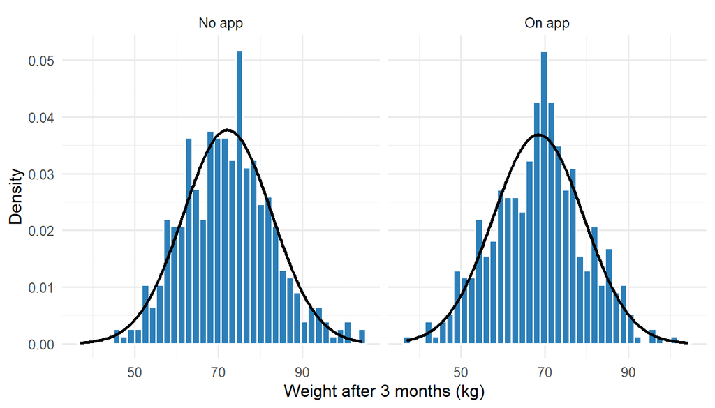

Weight after 3 months by trial arm, with fitted normal curves

```r
# ================================================================
# TASK 2. WEIGHT AT 3 MONTHS BETWEEN TRIAL ARMS
#    Test: independent-samples t-test
#    H0: mean weight at 3 months is the same in the No-app and On-app populations
#    Assumptions: independent groups; continuous outcome, approximately normal within
#                 each group; equal variances (Levene p > 0.05)
# ================================================================
# Normality: histograms with normal curve + Q-Q plots
hist_normal(data, "weight3mnths", g = "app", xlab = "Weight after 3 months (kg)")
```

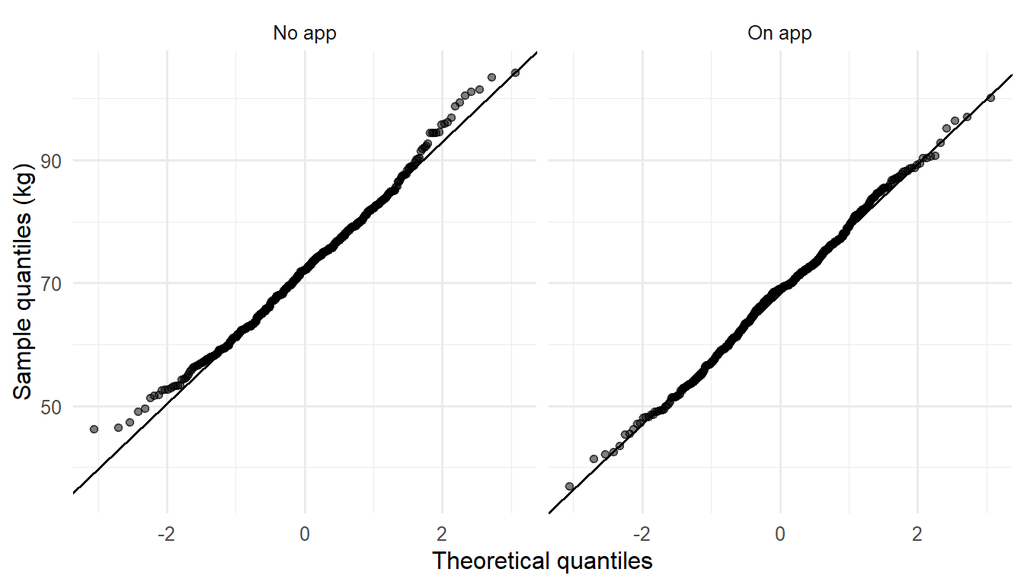

Normal Q-Q plots of weight after 3 months by trial arm

```r
ggplot(data, aes(sample = weight3mnths)) +
  stat_qq(alpha = .5) + stat_qq_line() + facet_wrap(~app) +
  labs(x = "Theoretical quantiles", y = "Sample quantiles (kg)")
```

```r
# Skewness and kurtosis within each arm
data %>%
  group_by(app) %>%
  summarise(N = n(),
            Skewness = DescTools::Skew(weight3mnths),
            Kurtosis = DescTools::Kurt(weight3mnths)) %>%
  kable(digits = 2, caption = "Shape of the weight distribution within each arm")
```

Shape of the weight distribution within each arm

| app | N | Skewness | Kurtosis |
| --- | --- | --- | --- |
| No app | 447 | 0.26 | 0.00 |
| On app | 448 | -0.01 | -0.18 |

```r
# Homogeneity of variance (centred on the mean)
lev <- car::leveneTest(weight3mnths ~ app, data = data, center = mean)
lev
```

```
Levene's Test for Homogeneity of Variance (center = mean)
       Df F value Pr(>F)
group   1  0.0652 0.7984
      893
```

```r
lev_F <- lev$"F value"[1]
lev_p <- lev$"Pr(>F)"[1]
```

The histograms follow the normal curves closely and the Q–Q points lie close to the line, so weight is approximately normal in both arms (skewness is close to 0). Levene’s test gives F = 0.065, p = 0.798, so there is no evidence that the variances differ, and the equal-variance t-test is appropriate.

## Results

```r
# Group statistics
data %>%
  group_by(app) %>%
  summarise(N = n(), Mean = mean(weight3mnths), SD = sd(weight3mnths), SE = SD / sqrt(N)) %>%
  kable(digits = 3, caption = "Group statistics: weight after 3 months (kg)")
```

Group statistics: weight after 3 months (kg)

| app | N | Mean | SD | SE |
| --- | --- | --- | --- | --- |
| No app | 447 | 72.192 | 10.582 | 0.501 |
| On app | 448 | 68.515 | 10.824 | 0.511 |

```r
# t-test (mean difference = No app minus On app)
tt <- t.test(weight3mnths ~ app, data = data, var.equal = TRUE)
tt
```

```
    Two Sample t-test

data:  weight3mnths by app
t = 5.1386, df = 893, p-value = 3.401e-07
alternative hypothesis: true difference in means between group No app and group On app is not equal to 0
95 percent confidence interval:
 2.272624 5.081423
sample estimates:
mean in group No app mean in group On app
            72.19203             68.51501
```

```r
cd <- rstatix::cohens_d(data, weight3mnths ~ app, var.equal = TRUE)

d2  <- unname(tt$estimate[1] - tt$estimate[2])
ci2 <- tt$conf.int
```

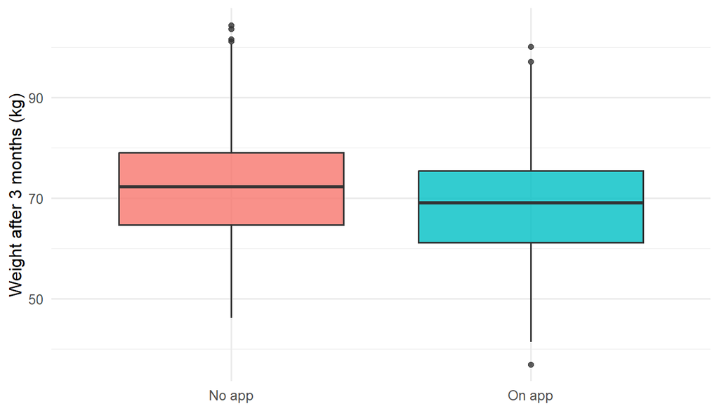

Weight after 3 months by trial arm

```r
ggplot(data, aes(app, weight3mnths, fill = app)) +
  geom_boxplot(show.legend = FALSE, alpha = .8) +
  labs(x = NULL, y = "Weight after 3 months (kg)")
```

## Interpretation

- **Size and direction:** mean weight at 3 months was 3.68 kg higher in the No-app arm (mean 72.19 kg) than in the On-app arm (mean 68.52 kg).
- **Significance:** t(893) = 5.14, p < 0.001. The p-value is below 0.05, so the null hypothesis is rejected.
- **Confidence interval:** the 95% CI for the mean difference is 2.27 to 5.08 kg. It excludes zero, consistent with the p-value. If the trial were repeated many times, 95% of such intervals would contain the true population mean difference.
- **Effect size:** Cohen’s d = 0.34 (small).

**Conclusion:** Participants using the dietary app weighed about 3.7 kg less at 3 months than those not using it.

# Task 3: Weight at 3 months between age groups

**Question:** Does weight at 3 months differ between the four age groups (18–24, 25–29, 30–34, 35–40)?

**Test:** One-way ANOVA, followed by Scheffé post-hoc comparisons.

**Justification:** The outcome is continuous, there are four independent groups, weight is approximately normal within each group and the variances are similar. Scheffé’s method controls the overall error rate across the six pairwise comparisons.

**Null hypothesis (H<sub>0</sub>):** The mean weight at 3 months is equal across all four age groups in the population.

**Assumptions:**

1. Independent groups (each participant belongs to one age group).
2. Weight at 3 months is approximately normal within each age group.
3. Equal variances across age groups (Levene’s test p > 0.05).

## Assumption checks

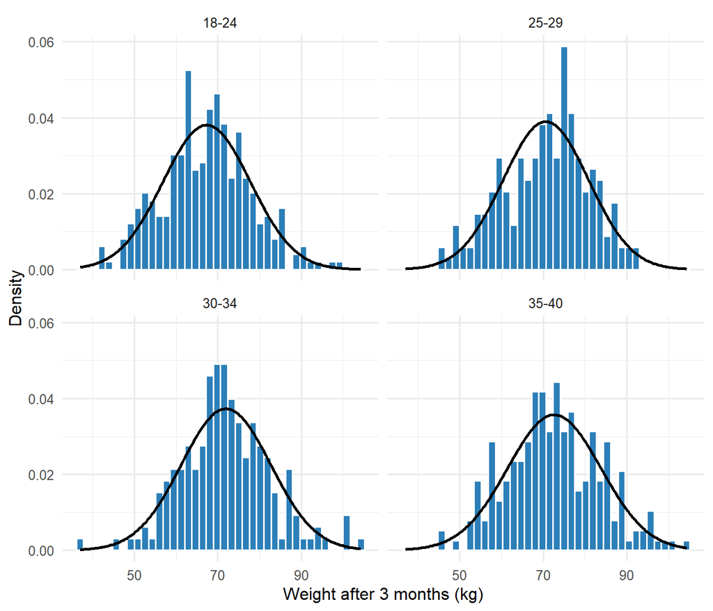

Weight after 3 months by age group, with fitted normal curves

```r
# ================================================================
# TASK 3. WEIGHT AT 3 MONTHS BETWEEN AGE GROUPS
#    Test: one-way ANOVA + Scheffe post-hoc
#    H0: mean weight at 3 months is equal across the four age groups
#    Assumptions: independent groups; continuous outcome, approximately normal within
#                 each age group; equal variances (Levene p > 0.05)
# ================================================================
hist_normal(data, "weight3mnths", g = "agegroup", xlab = "Weight after 3 months (kg)")
```

```r
lev3 <- car::leveneTest(weight3mnths ~ agegroup, data = data, center = mean)
lev3
```

```
Levene's Test for Homogeneity of Variance (center = mean)
       Df F value Pr(>F)
group   3  0.5422 0.6535
      891
```

```r
lev3_F <- lev3$"F value"[1]
lev3_p <- lev3$"Pr(>F)"[1]

data %>%
  group_by(agegroup) %>%
  summarise(N = n(), Mean = mean(weight3mnths), SD = sd(weight3mnths), SE = SD / sqrt(N),
            Lower95 = Mean - qt(.975, N - 1) * SE, Upper95 = Mean + qt(.975, N - 1) * SE,
            Min = min(weight3mnths), Max = max(weight3mnths)) %>%
  kable(digits = 2, caption = "Weight after 3 months (kg) by age group")
```

Weight after 3 months (kg) by age group

| agegroup | N | Mean | SD | SE | Lower95 | Upper95 | Min | Max |
| --- | --- | --- | --- | --- | --- | --- | --- | --- |
| 18-24 | 287 | 67.33 | 10.48 | 0.62 | 66.11 | 68.55 | 41.38 | 98.87 |
| 25-29 | 197 | 70.64 | 10.23 | 0.73 | 69.20 | 72.07 | 46.30 | 92.41 |
| 30-34 | 189 | 71.95 | 10.69 | 0.78 | 70.42 | 73.48 | 37.00 | 103.58 |
| 35-40 | 222 | 72.65 | 11.18 | 0.75 | 71.17 | 74.12 | 45.49 | 104.33 |

The distribution within each age group is approximately normal. Levene’s test gives F = 0.542, p = 0.653, so the variances can be treated as equal and the standard ANOVA is appropriate.

## Results

```r
fit3 <- aov(weight3mnths ~ agegroup, data = data)
an3  <- summary(fit3)[[1]]
an3
```

```
             Df Sum Sq Mean Sq F value   Pr(>F)
agegroup      3   4287 1428.98    12.6 4.51e-08 ***
Residuals   891 101049  113.41
---
Signif. codes:  0 '***' 0.001 '**' 0.01 '*' 0.05 '.' 0.1 ' ' 1
```

```r
eta2 <- an3$"Sum Sq"[1] / sum(an3$"Sum Sq")

# Scheffe post-hoc
sch3 <- DescTools::ScheffeTest(fit3, which = "agegroup", conf.level = 0.95)$agegroup %>%
  as.data.frame() %>%
  tibble::rownames_to_column("comparison")
sch3 %>%
  rename(`Comparison` = comparison, `Mean difference` = diff,
         `Lower 95% CI` = lwr.ci, `Upper 95% CI` = upr.ci, `Scheffe p` = pval) %>%
  kable(digits = 3, caption = "Scheffe post-hoc multiple comparisons")
```

Scheffe post-hoc multiple comparisons

| Comparison | Mean difference | Lower 95% CI | Upper 95% CI | Scheffe p |
| --- | --- | --- | --- | --- |
| 25-29-18-24 | 3.305 | 0.546 | 6.065 | 0.011 |
| 30-34-18-24 | 4.620 | 1.826 | 7.414 | 0.000 |
| 35-40-18-24 | 5.315 | 2.649 | 7.981 | 0.000 |
| 30-34-25-29 | 1.315 | -1.722 | 4.352 | 0.689 |
| 35-40-25-29 | 2.010 | -0.910 | 4.929 | 0.294 |
| 35-40-30-34 | 0.695 | -2.257 | 3.647 | 0.933 |

```r
sig_pairs <- sch3$comparison[sch3$pval < 0.05]
```

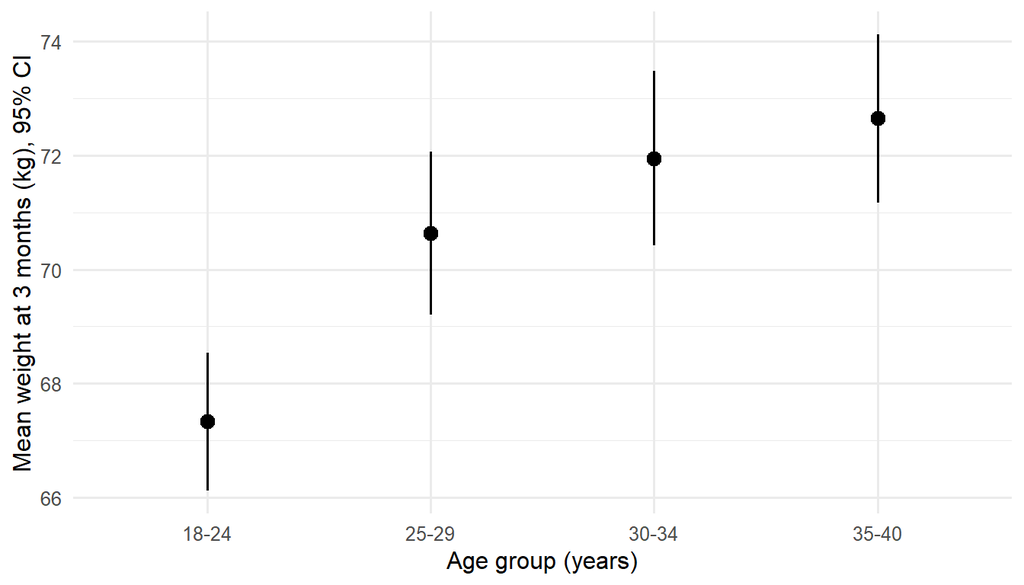

Mean weight at 3 months by age group with 95% confidence intervals

```r
data %>%
  group_by(agegroup) %>%
  summarise(m = mean(weight3mnths), se = sd(weight3mnths) / sqrt(n())) %>%
  ggplot(aes(agegroup, m)) +
  geom_pointrange(aes(ymin = m - 1.96 * se, ymax = m + 1.96 * se)) +
  labs(x = "Age group (years)", y = "Mean weight at 3 months (kg), 95% CI")
```

## Interpretation

- **ANOVA:** F(3, 891) = 12.60, p < 0.001. The null hypothesis is rejected: mean weight differs between at least two age groups. Age group explains 4.1% of the variance in weight (eta-squared = 0.041).
- **Post-hoc (Scheffé):** the statistically significant pairs are 25-29-18-24; 30-34-18-24; 35-40-18-24 (see the table for the mean differences and 95% CIs). Pairs not listed have confidence intervals that include zero.

**Conclusion:** Weight at 3 months differs by age group. The table above shows which age groups differ and by how much. In this sample the youngest group (18–24) has the lowest mean weight.

# Task 4: Residential area and trial arm

**Question:** Is there a relationship between residential area (urban, suburban, rural) and the trial arm?

**Test:** Pearson chi-square test of association (3 × 2 table).

**Justification:** Both variables are categorical (residential area is nominal with three categories, trial arm is binary), observations are independent and the table is large enough for the chi-square approximation.

**Null hypothesis (H<sub>0</sub>):** There is no association between residential area and trial arm in the population.

**Assumptions:**

1. Both variables are categorical and each participant appears once in the table (independent observations).
2. All expected cell counts are greater than 1.
3. At least 80% of cells have expected counts of 5 or more.
4. The test is computed from counts, not percentages.

## Assumption checks and results

```r
# ================================================================
# TASK 4. RESIDENTIAL AREA vs TRIAL ARM
#    Test: Pearson chi-square (3 x 2 table)
#    H0: no association between residential area and trial arm
#    Assumptions: categorical variables; independent observations (one row per participant);
#                 all expected counts > 1 and at least 80% of cells >= 5; counts, not percentages
# ================================================================
tab4 <- table(Residence = data$residence, Arm = data$app)
addmargins(tab4) %>% kable(caption = "Counts")
```

Counts

|  | No app | On app | Sum |
| --- | --- | --- | --- |
| urban | 146 | 231 | 377 |
| suburban | 176 | 158 | 334 |
| rural | 125 | 59 | 184 |
| Sum | 447 | 448 | 895 |

```r
pct4 <- round(prop.table(tab4, 1) * 100, 1)       # % within residential area
kable(pct4, caption = "Row percentages (% within residential area)")
```

Row percentages (% within residential area)

|  | No app | On app |
| --- | --- | --- |
| urban | 38.7 | 61.3 |
| suburban | 52.7 | 47.3 |
| rural | 67.9 | 32.1 |

```r
chi4 <- chisq.test(tab4, correct = FALSE)
chi4
```

```
    Pearson's Chi-squared test

data:  tab4
X-squared = 43.807, df = 2, p-value = 3.072e-10
```

```r
round(chi4$expected, 2) %>% kable(caption = "Expected counts")
```

Expected counts

|  | No app | On app |
| --- | --- | --- |
| urban | 188.29 | 188.71 |
| suburban | 166.81 | 167.19 |
| rural | 91.90 | 92.10 |

```r
v4 <- DescTools::CramerV(tab4)
```

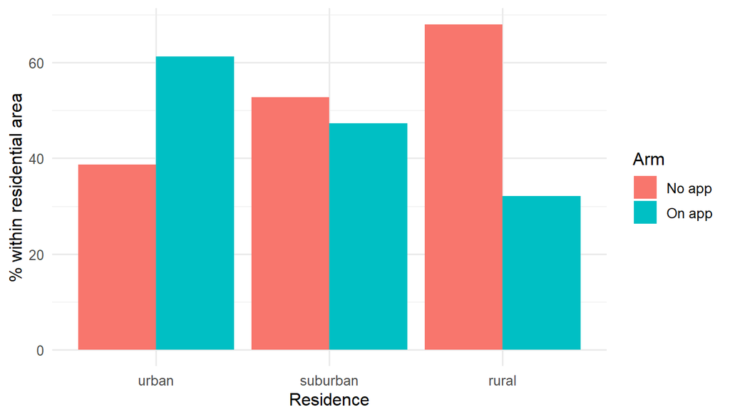

Trial arm by residential area (% within residential area)

```r
as.data.frame(pct4) %>%
  ggplot(aes(Residence, Freq, fill = Arm)) +
  geom_col(position = "dodge") +
  labs(y = "% within residential area")
```

The minimum expected count is 91.90 (above 1) and 0 of the 6 cells have an expected count below 5, so the expected-count assumptions are met. No cell is empty.

## Interpretation

- **Percentages:** the percentage of participants allocated to the On-app arm was 61.3% in urban areas, 47.3% in suburban areas and 32.1% in rural areas. The urban figure is 14.0 and 29.2 **percentage points** higher than the suburban and rural figures.
- **Significance:** Pearson chi-square(2) = 43.81, p < 0.001. The null hypothesis is rejected.
- **Strength:** Cramér’s V = 0.22.

**Conclusion:** There is an association between residential area and trial arm: urban residents were more likely, and rural residents less likely, to be in the On-app arm. Such an imbalance is unusual in a randomised trial, so the allocation process may deserve further scrutiny.

# Task 5: Change in weight from baseline to 3 months

**Question:** For all participants, does weight change between baseline and 3 months?

**Test:** Paired-samples t-test.

**Justification:** Weight was measured twice on the same participants (paired, continuous data) and the differences are approximately normal.

**Null hypothesis (H<sub>0</sub>):** The population mean of the differences (3 months − baseline) is zero.

**Assumptions:**

1. The observations are paired (same participants at two time points; confirmed by the study design).
2. The differences are approximately normally distributed.
3. There are no extreme outliers in the differences.

## Assumption checks

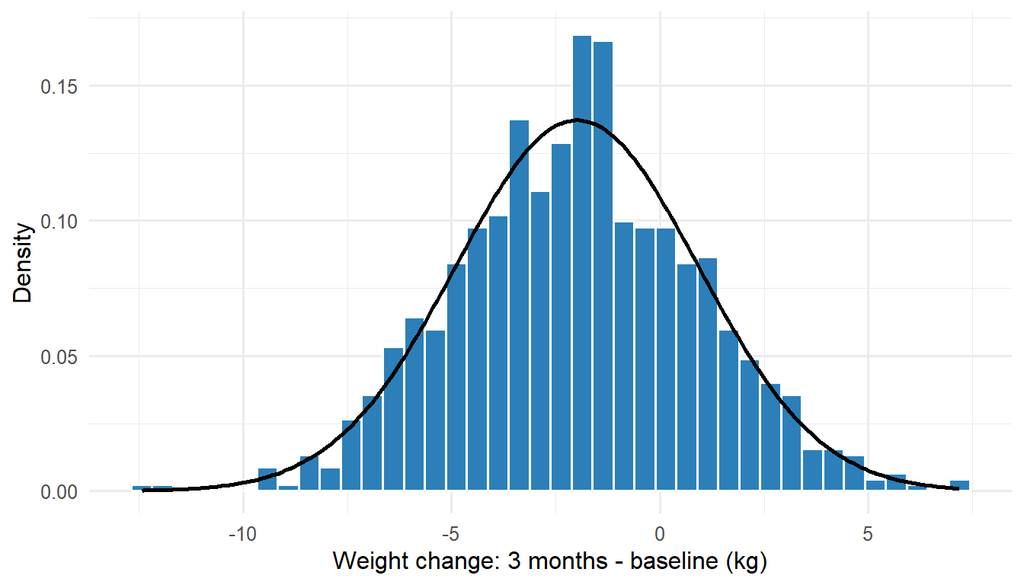

Distribution of weight change (3 months minus baseline)

```r
# ================================================================
# TASK 5. CHANGE IN WEIGHT, BASELINE TO 3 MONTHS (all participants)
#    Test: paired t-test
#    H0: mean of the differences (3 months - baseline) is zero
#    Assumptions: paired observations (same participants twice); differences approximately
#                 normal; no extreme outliers in the differences
# ================================================================
hist_normal(data, "weightdiff", xlab = "Weight change: 3 months - baseline (kg)")
```

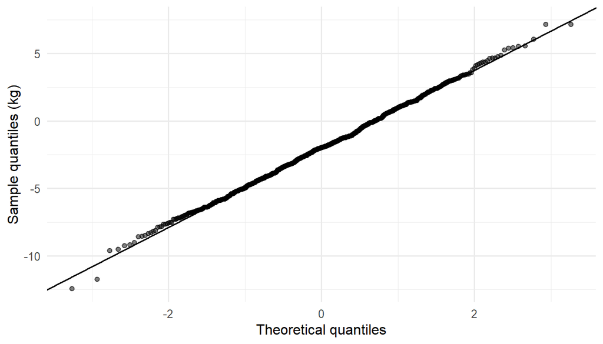

Normal Q-Q plot of weight change

```r
ggplot(data, aes(sample = weightdiff)) +
  stat_qq(alpha = .5) + stat_qq_line() +
  labs(x = "Theoretical quantiles", y = "Sample quantiles (kg)")
```

The histogram is bell-shaped and the Q–Q points follow the line, so the differences are approximately normal (skewness = 0.04). The boxplot rule flags 5 of 895 differences as outliers.

## Results

```r
tt5 <- t.test(data$weight3mnths, data$weightbase, paired = TRUE)
tt5
```

```
    Paired t-test

data:  data$weight3mnths and data$weightbase
t = -20.455, df = 894, p-value < 2.2e-16
alternative hypothesis: true mean difference is not equal to 0
95 percent confidence interval:
 -2.179453 -1.797845
sample estimates:
mean difference
      -1.988649
```

```r
dz5 <- mean(data$weightdiff) / sd(data$weightdiff)
```

## Interpretation

- **Size and direction:** the mean change was -1.99 kg (SD 2.91), so on average participants lost 1.99 kg between baseline and 3 months.
- **Significance:** t(894) = -20.46, p < 0.001. The null hypothesis is rejected.
- **Confidence interval:** the 95% CI for the mean change is -2.18 to -1.80 kg. It excludes zero.
- **Effect size:** Cohen’s d<sub>z</sub> = -0.68.

**Conclusion:** Across all participants there was a statistically significant change in weight over 3 months. This result pools both arms; Task 2 shows how the arms differ.

# Task 6: BMI category at 3 months and trial arm

**Question:** Is there a relationship between BMI category at 3 months and the trial arm?

**Test:** Chi-square test for trend (linear-by-linear association), 2 × 4 table.

**Justification:** Trial arm is binary and BMI category is ordinal (underweight < normal weight < overweight < obese). A test that uses the ordering has more power than the ordinary Pearson test.

**Null hypothesis (H<sub>0</sub>):** There is no association (no linear trend) between BMI category at 3 months and trial arm in the population.

**Assumptions:**

1. One variable is binary (trial arm) and the other is ordinal (BMI category), with equally spaced scores 1–4 used for the trend.
2. Observations are independent (each participant appears once).
3. All expected counts are greater than 1 and at least 80% of cells have expected counts of 5 or more.
4. The test is computed from counts, not percentages.

## Assumption checks and results

```r
# ================================================================
# TASK 6. BMI CATEGORY AT 3 MONTHS vs TRIAL ARM
#    Test: chi-square test for trend (linear-by-linear association), 2 x 4 table
#    H0: no association between BMI category and trial arm
#    Assumptions: binary arm and ordinal BMI category (scores 1-4); independent
#                 observations; all expected counts > 1 and at least 80% of cells >= 5;
#                 counts, not percentages
# ================================================================
tab6 <- table(Arm = data$app, BMI = data$BMIGrouping)
addmargins(tab6) %>% kable(caption = "Counts")
```

Counts

|  | underweight | normal weight | overweight | obese | Sum |
| --- | --- | --- | --- | --- | --- |
| No app | 22 | 255 | 137 | 33 | 447 |
| On app | 52 | 260 | 114 | 22 | 448 |
| Sum | 74 | 515 | 251 | 55 | 895 |

```r
pct6 <- round(prop.table(tab6, 1) * 100, 1)       # % within trial arm
kable(pct6, caption = "Row percentages (% within trial arm)")
```

Row percentages (% within trial arm)

|  | underweight | normal weight | overweight | obese |
| --- | --- | --- | --- | --- |
| No app | 4.9 | 57 | 30.6 | 7.4 |
| On app | 11.6 | 58 | 25.4 | 4.9 |

```r
chi6 <- chisq.test(tab6, correct = FALSE)          # Pearson, for expected counts

# Linear-by-linear association: M^2 = (N - 1) * r^2, df = 1
trend_test <- function(arm, score) {
  ok <- complete.cases(arm, score)
  r  <- cor(as.numeric(arm[ok]), as.numeric(score[ok]))
  M2 <- (sum(ok) - 1) * r^2
  tibble(statistic = M2, df = 1, p.value = pchisq(M2, 1, lower.tail = FALSE), r = r)
}
trend6 <- trend_test(data$app, data$BMIGrouping)
kable(trend6, digits = 4, caption = "Chi-square test for trend")
```

Chi-square test for trend

| statistic | df | p.value | r |
| --- | --- | --- | --- |
| 12.5105 | 1 | 4e-04 | -0.1183 |

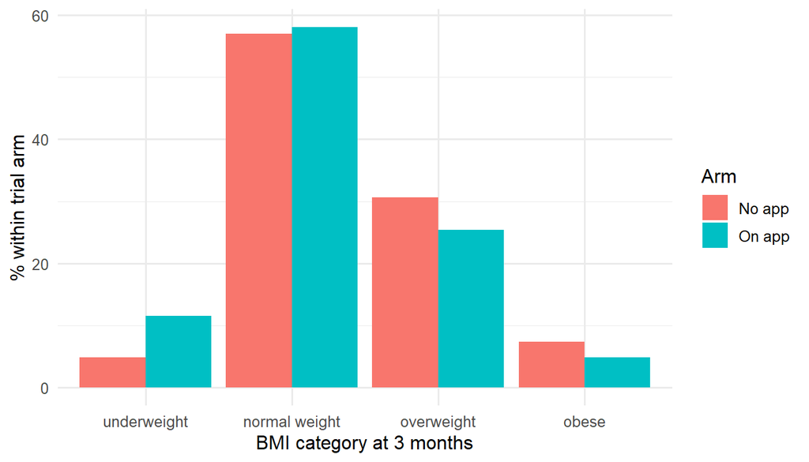

BMI category at 3 months by trial arm (% within trial arm)

```r
as.data.frame(pct6) %>%
  ggplot(aes(BMI, Freq, fill = Arm)) +
  geom_col(position = "dodge") +
  labs(x = "BMI category at 3 months", y = "% within trial arm")
```

The minimum expected count is 27.47 and 0 cells have an expected count below 5, so the expected-count assumptions are met.

## Interpretation

- **Overweight:** 25.4% (On app) vs 30.6% (No app), a difference of 5.2 percentage points.
- **Obese:** 4.9% vs 7.4% (difference 2.5 percentage points).
- **Underweight:** 11.6% vs 4.9% (difference 6.7 percentage points).
- **Normal weight:** 58.0% vs 57.0%.
- **Significance:** chi-square for trend(1) = 12.51, p < 0.001 (Pearson chi-square(3) = 16.52, p < 0.001). The null hypothesis is rejected.

**Conclusion:** BMI category at 3 months is associated with trial arm. App users were less likely to be overweight or obese but more likely to be underweight, which may merit clinical attention.

# Task 7: Orexigenic medication and exercise frequency

**Question:** Is there a relationship between use of orexigenic (appetite-stimulant) medication and the number of times exercise was taken for at least 30 minutes in the last month?

**Test:** Mann–Whitney U test (Wilcoxon rank-sum test).

**Justification:** The outcome is a discrete count that is clearly non-normal (right-skewed) and the two groups are independent, so a non-parametric test is used instead of the t-test.

**Null hypothesis (H<sub>0</sub>):** The distribution of monthly exercise sessions is the same in participants on and not on orexigenic medication.

**Assumptions:**

1. The two groups are independent (mutually exclusive).
2. The outcome is at least ordinal (here a numeric count).
3. The distributions are not normal, which justifies a rank-based test.
4. To interpret the result as a difference in medians, the two distributions should have a similar shape (otherwise the test compares overall distributions).
5. Participants with missing exercise data are excluded (available-case analysis).

## Assumption checks

```r
# ================================================================
# TASK 7. OREXIGENIC MEDICATION vs EXERCISE FREQUENCY
#    Test: Mann-Whitney U (Wilcoxon rank-sum)
#    H0: distribution of exercise sessions is the same with and without orexigenic medication
#    Assumptions: independent groups; outcome at least ordinal (discrete count); non-normal
#                 distributions; similar distribution shapes if interpreting as a difference
#                 in medians; participants with missing exercise data excluded
#    Analysis uses participants with exercise data (N = 845: Yes 246, No 599)
# ================================================================
data_ex <- data %>% drop_na(exercise)
nrow(data_ex)
```

```
[1] 845
```

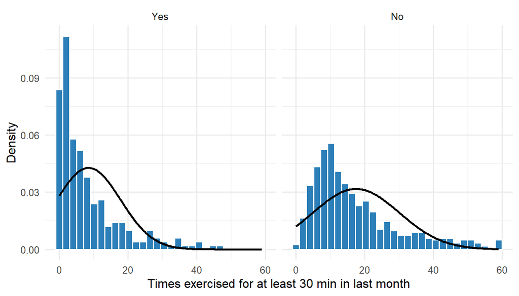

Exercise sessions in the last month by orexigenic medication

```r
hist_normal(data_ex, "exercise", g = "orexigenic", bins = 30,
            xlab = "Times exercised for at least 30 min in last month")
```

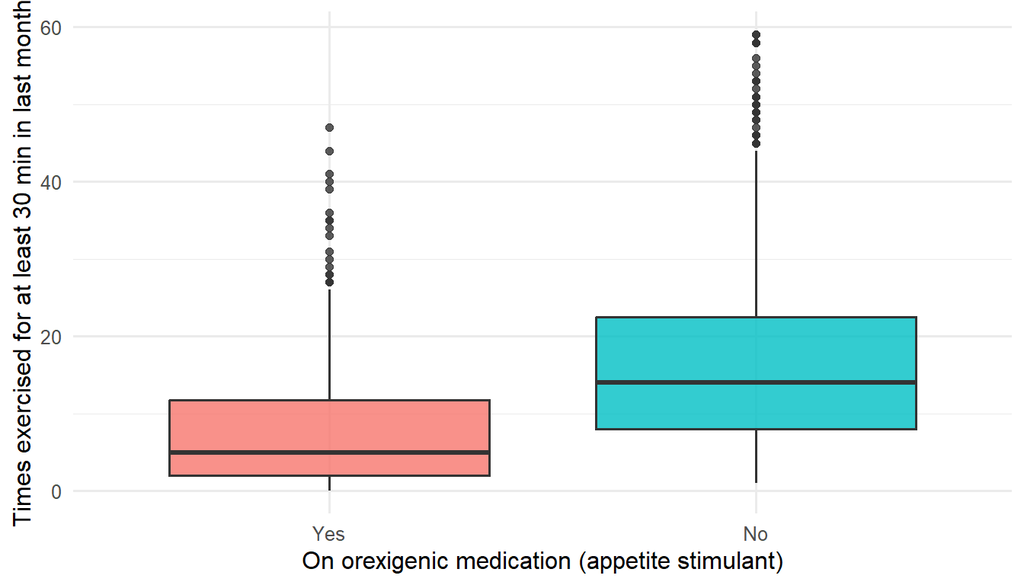

Exercise sessions in the last month by orexigenic medication

```r
ggplot(data_ex, aes(orexigenic, exercise, fill = orexigenic)) +
  geom_boxplot(show.legend = FALSE, alpha = .8) +
  labs(x = "On orexigenic medication (appetite stimulant)",
       y = "Times exercised for at least 30 min in last month")
```

```r
# Skewness within each group
data_ex %>%
  group_by(orexigenic) %>%
  summarise(N = n(), Skewness = DescTools::Skew(exercise)) %>%
  kable(digits = 2, caption = "Skewness of exercise sessions by group")
```

Skewness of exercise sessions by group

| orexigenic | N | Skewness |
| --- | --- | --- |
| Yes | 246 | 1.79 |
| No | 599 | 1.27 |

```r
# Percentiles
q7 <- data_ex %>%
  group_by(orexigenic) %>%
  summarise(N = n(),
            Q25    = quantile(exercise, .25, type = 6),
            Median = quantile(exercise, .50, type = 6),
            Q75    = quantile(exercise, .75, type = 6))
kable(q7, digits = 1, caption = "Exercise sessions in last month: median and quartiles")
```

Exercise sessions in last month: median and quartiles

| orexigenic | N | Q25 | Median | Q75 |
| --- | --- | --- | --- | --- |
| Yes | 246 | 2 | 5 | 12 |
| No | 599 | 8 | 14 | 23 |

```r
# Ranks
data_ex %>%
  mutate(rk = rank(exercise)) %>%
  group_by(orexigenic) %>%
  summarise(N = n(), `Mean rank` = mean(rk), `Sum of ranks` = sum(rk)) %>%
  kable(digits = 2, caption = "Ranks")
```

Ranks

| orexigenic | N | Mean rank | Sum of ranks |
| --- | --- | --- | --- |
| Yes | 246 | 264.24 | 65002 |
| No | 599 | 488.20 | 292433 |

```r
# Median (Q25, Q75) as text
med_iqr <- function(g) {
  r <- q7[q7$orexigenic == g, ]
  sprintf("%.0f (%.0f, %.0f)", r$Median, r$Q25, r$Q75)
}
```

## Results

```r
wt7 <- wilcox.test(exercise ~ orexigenic, data = data_ex,
                   exact = FALSE, correct = FALSE, conf.int = TRUE)
wt7
```

```
    Wilcoxon rank sum test

data:  exercise by orexigenic
W = 34621, p-value < 2.2e-16
alternative hypothesis: true location shift is not equal to 0
95 percent confidence interval:
 -8.999961 -6.000045
sample estimates:
difference in location
             -7.000026
```

```r
n7 <- table(data_ex$orexigenic)
U7 <- min(wt7$statistic, prod(n7) - wt7$statistic)
r7 <- rstatix::wilcox_effsize(data_ex, exercise ~ orexigenic)
```

## Interpretation

- **Sample:** 845 participants with exercise data (246 on orexigenic medication, 599 not).
- **Size and direction:** median (IQR) exercise sessions were 5 (2, 12) in participants on orexigenic medication and 14 (8, 23) in those not on medication. The Hodges–Lehmann estimate of the shift (Yes − No) is -7.0 sessions (95% CI -9.0 to -6.0).
- **Significance:** Mann–Whitney U = 34,621, p < 0.001. The null hypothesis is rejected.
- **Effect size:** r = 0.42 (moderate).

**Conclusion:** Use of orexigenic medication is associated with fewer sessions of at least 30 minutes of exercise per month. This is an association; it does not show that the medication causes lower activity.

# Appendix: Outliers and distributions (DescTools)

```r
num_cols <- c("height", "weightbase", "weight3mnths", "exercise", "weightdiff", "BMI3mnths")

# Outliers by the boxplot rule (beyond 1.5 x IQR) for every numeric variable
outlier_tbl <- map_dfr(num_cols, function(v) {
  x   <- data[[v]]
  out <- DescTools::Outlier(x, method = "boxplot", na.rm = TRUE)
  tibble(Variable = v, N = sum(!is.na(x)), n_outliers = length(out),
         pct_outliers = round(100 * length(out) / sum(!is.na(x)), 1),
         lowest_out  = if (length(out)) min(out) else NA_real_,
         highest_out = if (length(out)) max(out) else NA_real_)
})
kable(outlier_tbl, caption = "Boxplot-rule outliers per numeric variable")
```

Boxplot-rule outliers per numeric variable

| Variable | N | n_outliers | pct_outliers | lowest_out | highest_out |
| --- | --- | --- | --- | --- | --- |
| height | 895 | 4 | 0.4 | 1.46000 | 1.9600 |
| weightbase | 895 | 7 | 0.8 | 41.00000 | 103.0000 |
| weight3mnths | 895 | 10 | 1.1 | 37.00404 | 104.3251 |
| exercise | 845 | 45 | 5.3 | 42.00000 | 59.0000 |
| weightdiff | 895 | 5 | 0.6 | -12.44096 | 7.1856 |
| BMI3mnths | 895 | 12 | 1.3 | 33.60000 | 36.7000 |

```r
# Skewness, kurtosis and Shapiro-Wilk (judge normality mainly from the plots with N = 895)
map_dfr(num_cols, function(v) {
  x <- na.omit(data[[v]])
  tibble(Variable = v, N = length(x), Mean = mean(x), Median = median(x), SD = sd(x),
         Skewness = DescTools::Skew(x), Kurtosis = DescTools::Kurt(x),
         Shapiro_p = format.pval(shapiro.test(x)$p.value, digits = 3, eps = 0.001))
}) %>% kable(digits = 2, caption = "Distribution summary")
```

Distribution summary

| Variable | N | Mean | Median | SD | Skewness | Kurtosis | Shapiro_p |
| --- | --- | --- | --- | --- | --- | --- | --- |
| height | 895 | 1.73 | 1.73 | 0.08 | 0.03 | -0.12 | 0.135 |
| weightbase | 895 | 72.34 | 72.90 | 10.41 | 0.08 | -0.16 | 0.274 |
| weight3mnths | 895 | 70.35 | 70.26 | 10.85 | 0.10 | 0.00 | 0.485 |
| exercise | 845 | 14.88 | 11.00 | 12.40 | 1.34 | 1.42 | <0.001 |
| weightdiff | 895 | -1.99 | -1.96 | 2.91 | 0.04 | 0.04 | 0.812 |
| BMI3mnths | 895 | 23.68 | 23.50 | 3.82 | 0.33 | 0.10 | <0.001 |

Outliers flagged by the boxplot rule are not automatically errors. Shapiro–Wilk tests are very sensitive with 895 observations, so normality is judged mainly from the histograms and Q–Q plots.